# Actividad 4: Análisis estadístico avanzado: Análisis de varianza y repaso del curso

Gonzalo Mellizo-Soto

15 de enero 2019

# 1. Introducción

Lo primero es cargar el fichero de datos para poder realizar el análisis descriptivo y las visualizaciones pertinentes:

```r
sat <- read.csv('sat02.csv')
```

# 2. Análisis descriptivo y visualización

### Realizar un primer análisis descriptivo de los datos de la muestra.

Para realizar este análisis se van a utilizar las funciones `str` y `summary` de r-base:

```r
str(sat)
```

```
## 'data.frame':    38 obs. of  5 variables:
##  $ Wtype: Factor w/ 2 levels "PQ","Q": 1 1 1 1 2 1 1 1 1 2 ...
##  $ Etype: int  1 3 2 1 2 1 1 2 4 1 ...
##  $ S    : num  1.32 2.44 7.75 4.61 8.7 ...
##  $ Sex  : Factor w/ 2 levels "F","M": 1 1 1 1 2 1 2 2 1 2 ...
##  $ H    : num  38 26.8 31.5 23.8 27.7 ...
```

Se puede observar como las clases de las variabkes se corresponden al tipo adecuado para las variables numéricas y categoricas, aún así la variable `EType` se va a transformar a factor. El dataset consta de 38 observaciones de 5 variables.

```r
sat$Etype <- as.factor(sat$Etype)
summary(sat)
```

```
##  Wtype   Etype        S          Sex          H
##  PQ:22   1:13   Min.   : 1.319   F:16   Min.   :22.55
##  Q :16   2: 8   1st Qu.: 2.860   M:22   1st Qu.:26.98
##          3: 9   Median : 4.896          Median :30.57
##          4: 8   Mean   : 5.728          Mean   :30.27
##                 3rd Qu.: 8.669          3rd Qu.:33.50
##                 Max.   :10.000          Max.   :41.10
```

Por último vamos a hacer un repaso para ver si existe algún NA dentro del dataset

```r
sapply(sat, function(x) sum(is.na(x)))
```

```
## Wtype Etype     S   Sex     H
##     0     0     0     0     0
```

Como se observa no existen NAs en ninguna variable del dataset.

### Mostrar en un diagrama de caja la distribución de la satisfacción laboral de la muestra

Se va a utilizar el paquete `ggplot2` para realizar la representación:

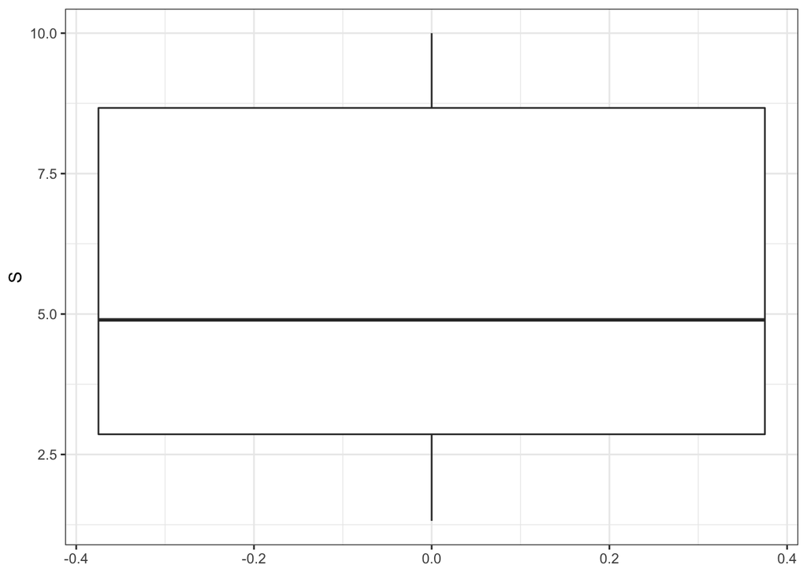

```r
ggplot(data = sat, aes(y=S)) +
  geom_boxplot()+
  theme_bw()
```

Como se puede observar en el gráfico la mediana se encuentra levemente por debajo de 5 y los datos se encuentran menos dispersos de la mediana al primer cuantil en comparación a la mediana con el tercero, la cual tiene una deispersión mayor de valores. Por otro lado, se puede observar como no existen outliers, dado que los valores se encuentran en las escala establecida (de 1 a 10).

### Mostrar en varios diagramas de caja la distribución de la satisfacción laboral según el tipo de trabajo, según el nivel educativo y según el sexo, respectivamente. Interpretar los gráficos brevemente.

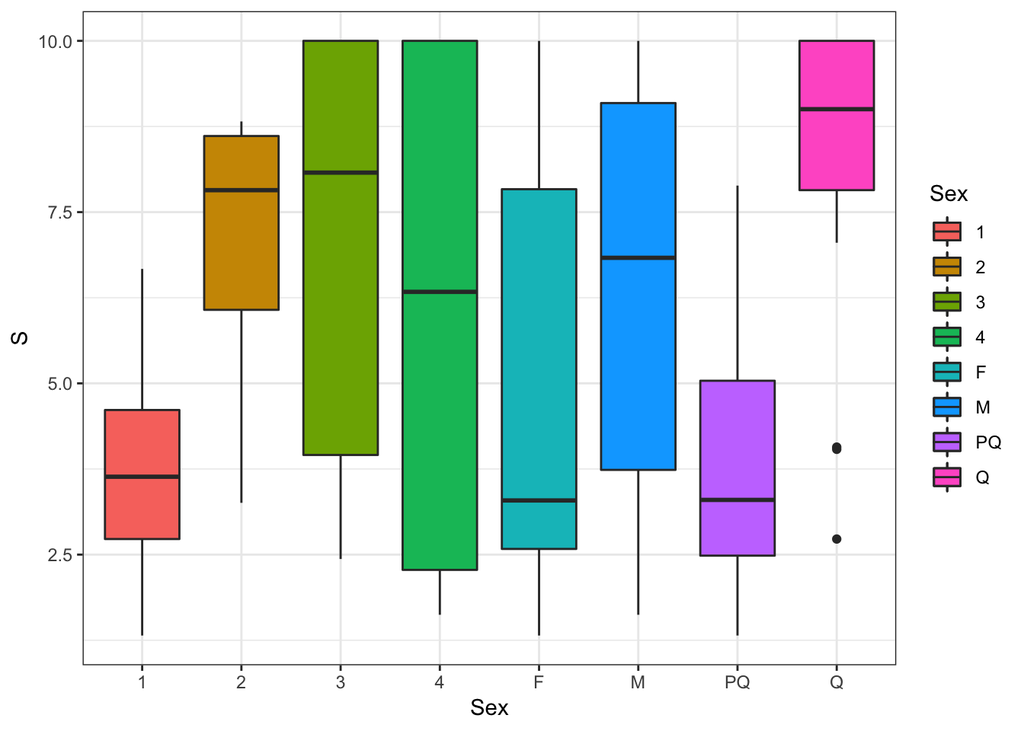

```r
ggplot(data=sat, aes(y=S))+
  geom_boxplot(aes(x=Sex, fill=Sex))+
  geom_boxplot(aes(x=Wtype, fill=Wtype))+
  geom_boxplot(aes(x=Etype, fill=Etype))+
  theme_bw()
```

En el gráfico anterior se han representado todos los diagramas de cajas en el mimsmo gráfico, para que así además de poder comprobar la relación de las categorias con la distribución, podemos observar si alguna de las variables mantienen relaciones parecidas con la variable dependiente.

Para los niveles de estudios se observa que la mayor parte de los trabajadores con estudios están comprendidos en valores mayores a 5. Se puede observar también como en su mayoría las personas sin estudios tiene una satisfacción baja sin embargo, los valores que podemos encontrar a los trabajadores con estudios universitarios nos encontramos con una grán dispersión de los datos y una mediana menor a los grupos 2 y 3 (primaria y secundaria/profesional).

En el caso del sexo las mujeres se encuentran con una distribución centrada en valores menores al cinco y muy dispersa para valores mayores a la mediana (valor cercano a 3). Por su parte los hombres se sienten más satisfechos en general con el trabajo.

Por último, destaca la diferencia entre las distribuciones de los trabajos poco cualificados a los cualificados, siendo los últimos trabajos con un grada muy alto de satisfacción y muy concentrados en el límite superior, salvo por dos outliers que se observan claramente. Para los no cualificados se observan valores más dispersos pero mucho más bajos que en la otra categoría.

# 3. Estadística Inferencial

## 3.1. Intervalo de confianza del nivel de satisfacción laboral

*Calcular el intervalo de confianza al 97 % de la satisfacción laboral de los trabajadores. A partir del valor obtenido, explique cómo se interpreta el resultado del intervalo de confianza.*

```r
intervalo <- 0.97
s <- sd(sat$S)
errorSd <- s/sqrt(length(sat$S))
valorCritico <- (1-intervalo)/2
tValue <- qt(c(valorCritico, 1-valorCritico), df = 37)
margenError <- tValue * errorSd
inicioIntervalo <- mean(sat$S) + margenError[1]
finIntervalo <- mean(sat$S) + margenError[2]

print(paste0("El intervalo de confianza es: [", inicioIntervalo, ',', finIntervalo, ']'))
```

```
## [1] "El intervalo de confianza es: [4.61103222232832,6.84553912764127]"
```

## 3.2. Test de dos muestras: satisfacción laboral en función del tipo de trabajo

*¿Hay diferencias significativas en la satisfacción laboral de los trabajadores que ocupan un puesto de trabajo cualificado y los que están en un lugar de trabajo poco cualificado?*

*Calcularlo para un nivel de confianza del 90 % y 95 %.*

### 3.2.1 Escribir la hipótesis nula y alternativa

- La hipotesis nula H0 es: “La satisfacción laboral de los trabajadores cualificados es igual a la satisfacción de de los trabajadores poco cualificados” mu(PQ) = mu(Q)
- La hipotesis alternativa (bilateral) es: “La satisfacción laboral de los trabajadores cualificados es distinta a la satisfacción de de los trabajadores poco cualificados” mu(Q) != mu(PQ)

### 3.2.3. Calcular el estadistico de contraste, el valor critico y el valor p.

El estadistico de contraste es el siguiente: (x1 - x2) / (S1-2)

```r
# Para intervalo de confianza del 90%
x1 <-  mean(sat[sat$Wtype == "Q",]$S)
x2 <- mean(sat[sat$Wtype == "PQ",]$S)
sigma1 <- sd(sat[sat$Wtype == "Q",]$S)
sigma2 <- sd(sat[sat$Wtype == "PQ",]$S)
n1<- nrow(sat[sat$Wtype == "Q",])
n2<- nrow(sat[sat$Wtype == "PQ",])

s1_2 = sqrt((sigma1^2 / n1) + (sigma2^2 / n2))

t <- (x1 - x2) / (s1_2)
print(paste("El estadistico del contraste es: ", t))
```

```
## [1] "El estadistico del contraste es:  5.71348146772825"
```

```r
valCritico <- qt(p = c(0.90, 0.10), df = 37)
print(paste("El valor critico es: ", valCritico))
```

```
## [1] "El valor critico es:  1.30485438149762"
## [2] "El valor critico es:  -1.30485438149762"
```

```r
p_value <-   2*(pt(q = t, df =  30, lower.tail = FALSE))
print(paste("El p-valor es: ", p_value))
```

```
## [1] "El p-valor es:  3.11322517727725e-06"
```

```r
# Para el intervalo de confianza de 0.95
t <- (x1 - x2) / (s1_2)
print(paste("El estadistico del contraste es: ", t))
```

```
## [1] "El estadistico del contraste es:  5.71348146772825"
```

```r
valCritico <- qt(p = c(0.95, 0.05), df = 37)
print(paste("El valor critico es: ", valCritico))
```

```
## [1] "El valor critico es:  1.68709361959626"
## [2] "El valor critico es:  -1.68709361959626"
```

```r
p_value <-   2*(pt(q = t, df = 30, lower.tail = FALSE))
print(paste("El p-valor es: ", p_value))
```

```
## [1] "El p-valor es:  3.11322517727725e-06"
```

### 3.2.4. Interpretar el resultado y dar respuesta a la pregunta planteada

Como se puede observar para ambas, el estadístico se encuentra fuera del intervalo del valor crítico para ambos casos y coincide con que el p-valor es menor del 5% por lo que se rechaza la hipótesis nula. Tal y como se ha observado en los gráficos anteriores existe una diferencia muy amplia entre ambos.

## 3.3 Test de dos muestras: satisfacción laboral en función del sexo

*¿Se puede afirmar que las mujeres tienen una satisfacción laboral inferior a la de los hombres? Calcularlo para un nivel de confianza del 90 % y 95 %.*

### 3.3.1 Escribir la hipótesis nula y alternativa

- La hipotesis nula H0 es: “La satisfacción laboral de los trabajadores es igual a la satisfacción de las trabajadoras” mu(M) = mu(F)
- La hipotesis alternativa (bilateral) es: “La satisfacción laboral de los trabajadores es distinta a la satisfacción de las trabajadoras” mu(M) != mu(F)

### 3.3.3. Calcular el estadistico de contraste, el valor critico y el valor p.

El estadistico de contraste es el siguiente: (x1 - x2) / (S1-2)

```r
# Para intervalo de confianza del 90%
x1 <-  mean(sat[sat$Sex == "M",]$S)
x2 <- mean(sat[sat$Sex == "F",]$S)
sigma1 <- sd(sat[sat$Sex == "M",]$S)
sigma2 <- sd(sat[sat$Sex == "F",]$S)
n1<- nrow(sat[sat$Sex == "M",])
n2<- nrow(sat[sat$Sex == "F",])

s1_2 = sqrt((sigma1^2 / n1) + (sigma2^2 / n2))

t <- (x1 - x2) / (s1_2)
print(paste("El estadistico del contraste es: ", t))
```

```
## [1] "El estadistico del contraste es:  1.71415130353792"
```

```r
valCritico <- qt(p = c(0.90, 0.10), df = 37)
print(paste("El valor critico es: ", valCritico))
```

```
## [1] "El valor critico es:  1.30485438149762"
## [2] "El valor critico es:  -1.30485438149762"
```

```r
p_value <-   2*(pt(q = t, df =  30, lower.tail = FALSE))
print(paste("El p-valor es: ", p_value))
```

```
## [1] "El p-valor es:  0.0968166492191673"
```

```r
# Para el intervalo de confianza de 0.95
t <- (x1 - x2) / (s1_2)
print(paste("El estadistico del contraste es: ", t))
```

```
## [1] "El estadistico del contraste es:  1.71415130353792"
```

```r
valCritico <- qt(p = c(0.95, 0.05), df = 30)
print(paste("El valor critico es: ", valCritico))
```

```
## [1] "El valor critico es:  1.69726088659396"
## [2] "El valor critico es:  -1.69726088659396"
```

```r
p_value <-   2*(pt(q = t, df = 30, lower.tail = FALSE))
print(paste("El p-valor es: ", p_value))
```

```
## [1] "El p-valor es:  0.0968166492191673"
```

### 3.3.4. Interpretar el resultado y dar respuesta a la pregunta planteada

En este caso, dependiendo del nivel de confianza podemos rechazar o no la hipótesis nula. En caso del nivel al 90% no se cumple que el p-valor > 0.1, por lo que se rechaza la hipótesis nula de que la satisfacción media es igual entre hombres y mujeres. Por el otro lado, se cumple que el p-valor es mayor a 0.05 por lo que no se rechaza la hipótesis.

# 4. Regresión

## 4.1 Modelo de regresión

*Aplicar un modelo de regresión lineal múltiple que use como variables explicativas el número de horas, el sexo, el nivel de educación y el tipo de trabajo y como variable dependiente la satisfacción laboral. Especificar en el nivel base (en el relevel): para la variable sexo, la categoría ‘F’, por la variable educación, la categoría ‘1’, y por la variable tipo de trabajo, la categoría ‘PQ’*

Procedamos a realizar la regresión lineal a las variables seleccionadas:

```r
sat$Sex <- relevel(sat$Sex,  ref = 'F')
sat$Etype <- relevel(sat$Etype,  ref = '1')
sat$Wtype <- relevel(sat$Wtype,  ref = 'PQ')
sat_lm <- lm(S ~ H + Sex + Etype + Wtype, data = sat)
summary(sat_lm)
```

```
##
## Call:
## lm(formula = S ~ H + Sex + Etype + Wtype, data = sat)
##
## Residuals:
##     Min      1Q  Median      3Q     Max
## -4.1736 -1.5668  0.1855  1.7080  3.2844
##
## Coefficients:
##             Estimate Std. Error t value Pr(>|t|)
## (Intercept)  4.39778    2.49245   1.764   0.0875 .
## H           -0.05711    0.07770  -0.735   0.4679
## SexM         0.63932    0.74585   0.857   0.3979
## Etype2       2.50859    0.95900   2.616   0.0136 *
## Etype3       1.34802    1.03121   1.307   0.2008
## Etype4       1.17412    0.99334   1.182   0.2462
## WtypeQ       3.78734    0.79076   4.789 3.92e-05 ***
## ---
## Signif. codes:  0 '***' 0.001 '**' 0.01 '*' 0.05 '.' 0.1 ' ' 1
##
## Residual standard error: 2.119 on 31 degrees of freedom
## Multiple R-squared:  0.596,  Adjusted R-squared:  0.5178
## F-statistic: 7.621 on 6 and 31 DF,  p-value: 4.416e-05
```

## 4.2 Interpretación

*Interpretar el modelo de regresión resultante, indicando cuáles regresores son significativos. Explicar si existen diferencias significativas debidas al sexo y si están, en qué sentido. Repetir para el resto de variables*

En este caso no se aprecia que el sexo se trate de un regresor significativo, pero si que favorece aunque en menor medida que ciertas variables en la felicidad (un poco mas significativa para los hombres con respecto a las mujeres). Por otro lado, podemos observar ciertas variables más significativas para la relación a la satisfacción, concretamente el tipo de trabajo, que tal y como se ha observado en los gráficos un trabajo cualificado repercute más y por tanto se muestra como un regresor significativo en la regresión lineal. En menor medida lo observamos en “Etype2” que como se ha mostrado existe un salto significativo entre la clase 1 y la clase 2.

## 4.3 Predicción

*Aplicar el modelo de regresión para predecir la satisfacción laboral de un hombre, que trabaja 40h semanales (h/s), de nivel de estudios universitarios y con un trabajo cualificado. Comparar el resultado con el de un hombre, que trabaja 40 h/s, de nivel de estudios universitarios, y trabajo poco cualificado.*

```r
print(paste0("La satisfacción estimada es: ",predict(sat_lm, data.frame(H = 40, Etype = '4', Wtype = "Q", Sex = "M"))))
```

```
## [1] "La satisfacción estimada es: 7.71418816480179"
```

```r
print(paste0("La satisfacción estimada es: ",predict(sat_lm, data.frame(H = 40, Etype = '4', Wtype = "PQ", Sex = "M"))))
```

```
## [1] "La satisfacción estimada es: 3.92684875671074"
```

## 4.4 Interpretación de la predicción

*Interpretar los resultados obtenidos en el apartado anterior. Concretamente, comentar los aspectos siguientes:*

- *¿Consideras que el modelo será preciso, teniendo en cuenta los valores de R2 y p − value obtenidos?*
- *¿Cómo se puede interpretar la diferencia de satisfacción laboral entre los dos individuos, a partir de los coeficientes del modelo de regresión?*

Considerando el valor de R2 (0.596) y el p-valor (4.416e-05) no podemos considerar que el modelo explique bien, dado que el valor de R2 nos indica que no se ajusta demasiado a los valores, mientras que el p-valor tiene un valor muy cercano a cero, lo que indica una mayor significación del modelo, por lo tanto no se puede concluir a ciencia cierta que el modelo tenga una gran precisión.

La diferencia se puede interpretar reemplazando los datos de los individuos utilizando los coeficientes y se puede observar que producto es que tiene mayor peso. En este caso, se puede observar como al tener un trabajo cualificado la felicidad aumenta en el coeficiente WtypeQ, el cual sumaría 3.78 con respecto al no cualificado, tal y como se puede observar en la predicción.

## 4.5 Intervalos de predicción

*Calcular los intervalos de predicción de los dos individuos al 95 %. Para hacerlo, puedes añadir a la función predict() el argumento intervalo = “prediction”. Para especificar el nivel de confianza puede usar el argumento level (por defecto es 0.95). Interprete los resultados*

```r
print(
             predict(sat_lm,
                     data.frame(H = 40, Etype = '4',
                                Wtype = "Q", Sex = "M"),
                     interval = "predict", level = 0.95))
```

```
##        fit      lwr      upr
## 1 7.714188 2.814585 12.61379
```

```r
print(
             predict(sat_lm,
                     data.frame(H = 40, Etype = '4',
                                Wtype = "PQ", Sex = "M"),
                     interval = "predict", level = 0.95))
```

```
##        fit       lwr      upr
## 1 3.926849 -1.100521 8.954218
```

En este caso el intervalo de predicción devuelto para ambos, difieren en gran medida y se trata de un intervalo de una gran amplitud entre el valor mínimo y el máximo (casi 10 puntos).

## 4.6 Ajuste del modelo

*Analizar la adecuación del modelo a partir del análisis gráfico de residuos. Para esto, puede utilizar la instrucción plot() pasando como argumento el modelo de regresión lineal. Para saber cómo interpretar los gráficos de residuos, consulte el enlace siguiente: http://data.library.virginia.edu/diagnostic-plots/*

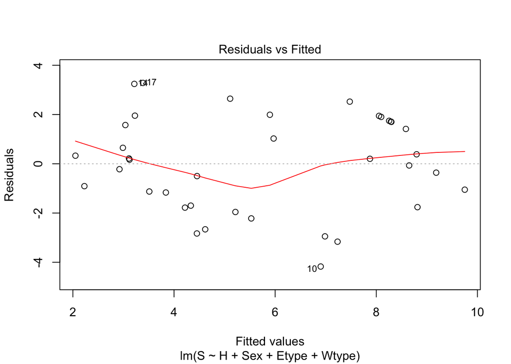

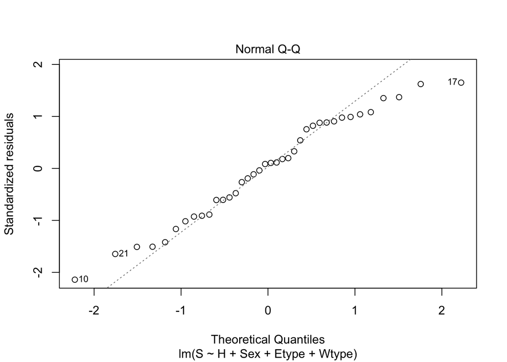

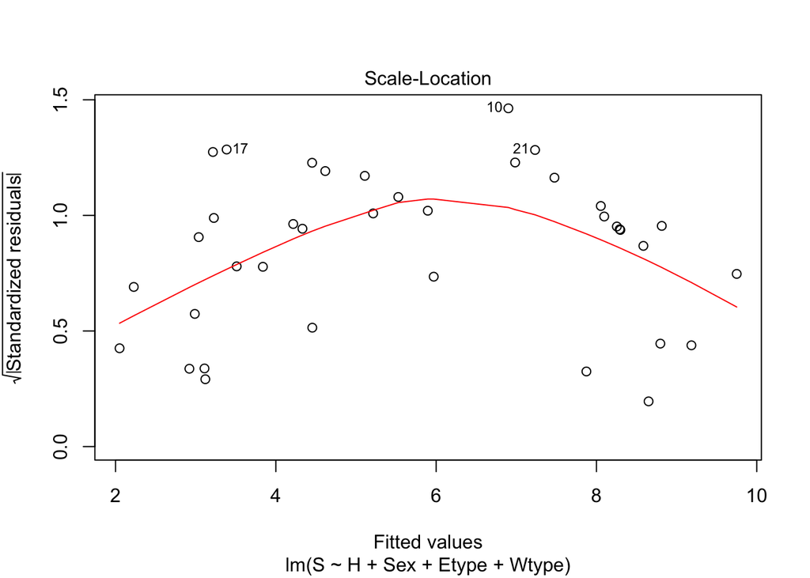

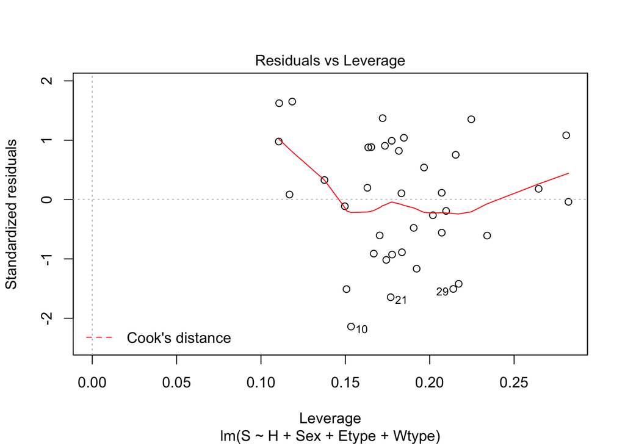

```r
plot(sat_lm)
```

Para el gráfico QQ se muestra si los datos residuales están distribuidos normalmente y en este caso se aprecia como los valores se ajustan en cierta medida a la recta, por lo que se puede asumir que guardan cierta normalidad.

Se muestra si los residuales se encuentran repartidos uniformemente con los rangos de los predictores, por lo que a más horizontal la recta mayor uniforme y como se aprecia en este caso se trata de una parábola lo que nos indica que los residuales se encuentran más dispersos para valores entre 4 y 8 de los valores predecidos.

# 5.Análisis de varianza unifactorial

*A continuación, nos preguntamos si el nivel de satisfacción laboral está influido por el nivel de estudios. Dado que esta variable tiene cuatro niveles, se aplicará análisis de varianza.*

## 5.1 Hipótesis nula y alternativa

- H0: las submuestras por nivel de estudios son iguales, u1 = u2 = u3 = u4
- H1: las submuestras por nivel de estudios son distintas

## 5.2 Modelo

*Calcular el análisis de varianza, usando la función aov(). Interpretar el resultado del análisis, teniendo en cuenta los valores Sum Sq, Mean SQ, F y Pr (> F)*

```r
tapply(sat$S, sat$Etype, mean)
```

```
##        1        2        3        4
## 3.877328 6.912927 7.037076 6.079061
```

```r
aov_fit = lm(S ~ Etype, sat)
anova(aov_fit)
```

```
## Analysis of Variance Table
##
## Response: S
##           Df  Sum Sq Mean Sq F value  Pr(>F)
## Etype      3  72.166 24.0554   3.003 0.04388 *
## Residuals 34 272.356  8.0105
## ---
## Signif. codes:  0 '***' 0.001 '**' 0.01 '*' 0.05 '.' 0.1 ' ' 1
```

Para este caso nos podemos fijar en como el p-valor es menor de grado de significación del 0.05 por lo que puede concluir con que existen diferencias según los grupos de estudios.

# 5.3 Cálculos

*Con el fin de profundizar en la comprensión del modelo ANOVA, calcular manualmente la suma de cuadrados intra y la suma de cuadrados entre grupos. Los resultados deben coincidir con el resultado del modelo ANOVA. Como referencia, puedes obtener las fórmulas de López-Roldán y Fachelli (2015), páginas 29-33.*

```r
aov.info = function(x){
  return( data.frame(n = length(x), meanVal = mean(x), sdVal = sd(x)))
}

print(aov.info(as.numeric(sat$S)))
```

```
##    n  meanVal    sdVal
## 1 38 5.728286 3.051463
```

```r
data <- tapply(sat$S, sat$Etype, aov.info)
print(data)
```

```
## $`1`
##    n  meanVal    sdVal
## 1 13 3.877328 1.553916
##
## $`2`
##   n  meanVal    sdVal
## 1 8 6.912927 2.319241
##
## $`3`
##   n  meanVal    sdVal
## 1 9 7.037076 3.203398
##
## $`4`
##   n  meanVal    sdVal
## 1 8 6.079061 4.202624
```

```r
meansofgroups <- function(groupsname){ # function to calculate means of groups

  mog <- mean(groupsname, na.rm = TRUE)
  return(mog)
}

total_mean <- sum(sat$S)/nrow(sat)

means_of_groups <- c(data$`1`$meanVal, data$`2`$meanVal, data$`3`$meanVal ,data$`4`$meanVal)
ss <- function(ss_data, group_mean){  #function to calculate sum of squares
  w <- 0
  for(i in seq_along(ss_data)) {
    w[i] <- ss_data[i] - group_mean
  }
  return(w^2)
}

ss_within <- sum(ss(sat$S[sat$Etype == '1'], means_of_groups[1]), ss(sat$S[sat$Etype == '2'],means_of_groups[2]), ss(sat$S[sat$Etype == '3'], means_of_groups[3]),ss(sat$S[sat$Etype == '4'], means_of_groups[4]), na.rm = TRUE)
changetomean <- function(changetomean_data, means_groups){ # function to change all obs to means of corresponding groups
  changetomean_data[which(changetomean_data != 0)] <- means_groups
  return(changetomean_data[which(changetomean_data != 0)])
}

ss_between <- sum(ss(changetomean(sat$S[sat$Etype == '1'], means_of_groups[1]), total_mean),
                  ss(changetomean(sat$S[sat$Etype == '2'], means_of_groups[2]), total_mean),
                  ss(changetomean(sat$S[sat$Etype == '3'], means_of_groups[3]), total_mean),
                  ss(changetomean(sat$S[sat$Etype == '4'], means_of_groups[4]), total_mean))
print(paste0("SSD_I: ", ss_within))
```

```
## [1] "SSD_I: 272.356394278548"
```

```r
print(paste0("SSD_E: ", ss_between))
```

```
## [1] "SSD_E: 72.1663139352109"
```

# 6. Adecuación del modelo

*Validar la adecuación del modelo ANOVA. Puedes consultar López-Roldán y Fachelli (2015), gráfico III.8.6, página 25*

## 6.1 Visualización de la adecuación del modelo

*Mostrar visualmente la adecuación del modelo ANOVA. Puedes usar plot sobre el modelo ANOVA resultante. En los apartados siguientes se pide la interpretación de estos gráficos*

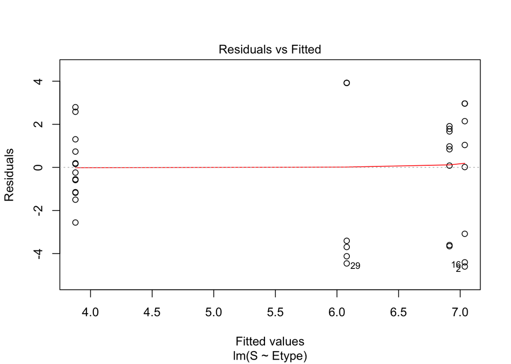

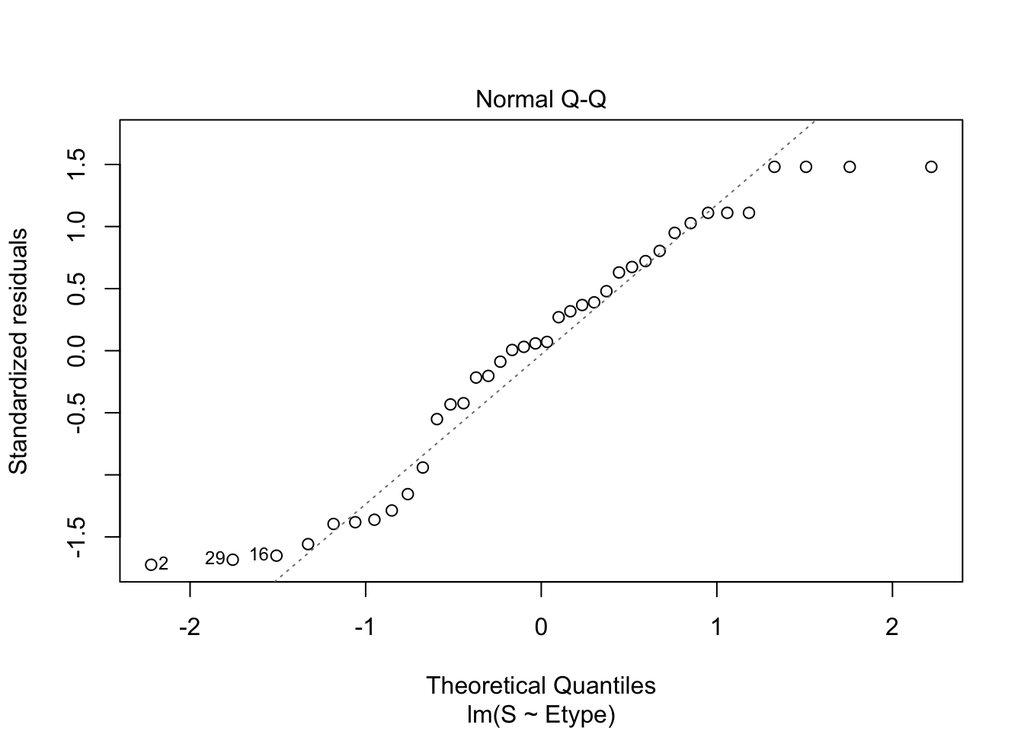

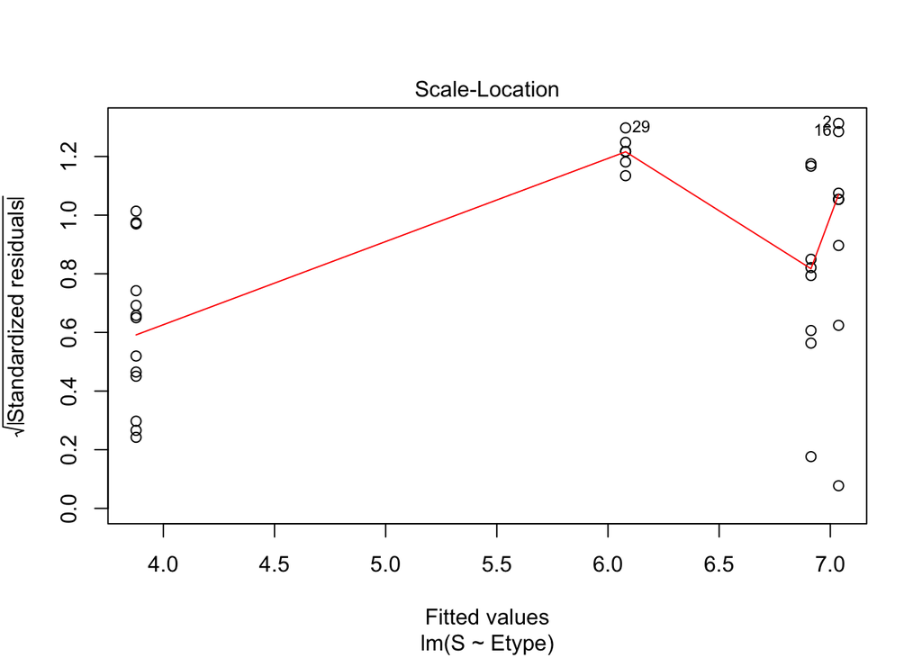

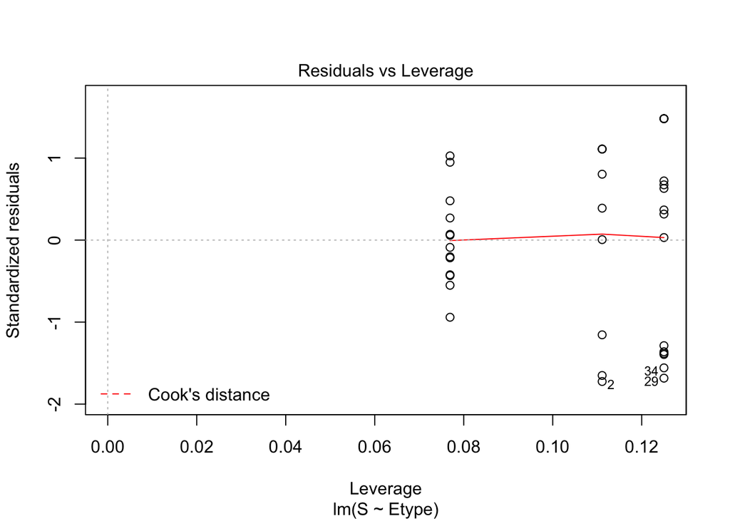

```r
plot(aov_fit)
```

## 6.2. Normalidad de los residuos

*Interpretar la normalidad de los residuos a partir del gráfico Normal Q-Q que se muestra en el apartado anterior*

En este caso paar considerar como normal la variable, los puntos deberian de estar lo mas cercano posible a la línea. en este caso podemos observar como en ciertas partes se encuentran picos e incluso similitud entre los puntos (x=1, y=1). Por ello, la distribución mostrara ciertos picos o sesgos en los extremos, aún así se adpata bastante a la línea por lo que podría considerarse normal.

## 6.3. Homoscedasticidad los residuos

*Los gráficos “Residuales vs Fitted”, “Scale-Location” y “Residuales vs Factor levels” dan información sobre la homocedasticidad de los residuos. Interpretar estos gráficos.*

*Puedes consultar información complementaria sobre cómo interpretar estos gráficos en los siguientes enlaces:*

- https://support.minitab.com/en-us/minitab-express/1/help-and-how-to/modeling-statistics/anova/how-to/one-way-anova/interpret-the-results/all-statistics-and-graphs/#normal-probability-plot-of-the-residuals
- https://support.minitab.com/en-us/minitab-express/1/help-and-how-to/modeling-statistics/anova/how-to/two-way-anova/interpret-the-results/all-statistics-and-graphs/
- Residuals vs Fitted: En este caso nos podemos encontrar como los puntos no siguen un patrón similar y distribuciones dispares entre ellas, además ciertos puntos aparecen en los extremos por lo que podemos considerarlos como puntos dispares e influyentes. En este caso, se consideraría que se trata de una varianza NO constante
- Scale-Location: en este caso, se puede observar como puede encontrarse un patrón creciente, a pesar de la cantidad de puntos, se observa la tendencia en el gráfico
- Residuales vs Factor levels: se puede observar como la apmlitud aumenta según la distancia y tampoco muestra casos extremos en cuanto a la distancia

Por lo tanto, podría suponerse que existen diferencias en las varianzas.

## 6.4. ANOVA no paramétrico

### 6.4.1. Kruskal-Wallis

*Si las condiciones de aplicación de ANOVA no se cumplen, entonces se suele aplicar un test no paramétrico. El test Kruskal-Wallis es el equivalente no paramétrico de ANOVA. Aplicar el test usando la función kruskal.test() e interpretar el resultado.*

*Puedes consultar el siguiente enlace:*

https://www.sheffield.ac.uk/polopoly_fs/1.714570!/file/stcp-karadimitriou-KW.pdf

```r
kruskal.test(sat$S,sat$Etype)
```

```
##
##  Kruskal-Wallis rank sum test
##
## data:  sat$S and sat$Etype
## Kruskal-Wallis chi-squared = 5.5492, df = 3, p-value = 0.1357
```

Se observa como el valor se encuentra por encima del nivel de significación 5% por lo que no se puede considerar que existan diferencias significativas en las varianzas

### 6.4.2. Interpretación

*Explicar en qué se diferencia el cálculo de ANOVA del cálculo del test de Kruskal-Wallis. Si el test de Kruskal-Wallis no tiene las mismas restricciones de aplicación que el test ANOVA, ¿por qué crees que se continúa aplicando ANOVA, si las condiciones de satisfacción lo permiten, en lugar de Kruskal-Wallis?*

Ambos métodos se diferencia en que ANOVA es un método paramétrico y debe de cumplir ciertas condiciantes para poder aplicarlo, mientras que Kruskal-Wallis se trata de un método no-paramétrico que puede aplicarse a variables con distribuciones no gaussianas. En este caso, los test paramétricos permiten analizar mejor el test en cuestión, por eso se tiende a utilizar test paramétricos frente a los no paramétricos, dado que en ciertos casos los p-valores pueden diferir notablemente.

```r
tapply(sat$S, sat$Etype, shapiro.test)
```

```
## $`1`
##
##  Shapiro-Wilk normality test
##
## data:  X[[i]]
## W = 0.95798, p-value = 0.7222
##
##
## $`2`
##
##  Shapiro-Wilk normality test
##
## data:  X[[i]]
## W = 0.7627, p-value = 0.01127
##
##
## $`3`
##
##  Shapiro-Wilk normality test
##
## data:  X[[i]]
## W = 0.82756, p-value = 0.04192
##
##
## $`4`
##
##  Shapiro-Wilk normality test
##
## data:  X[[i]]
## W = 0.70887, p-value = 0.002837
```

El test sugiere que no todos los grupos en la variable son normales, lo que concordaría con utilizar el test no paramétrico de Kruskal-Wallis.

# 7. ANOVA multifactorial

*A continuación, se quiere evaluar el efecto de la calificación del trabajo combinado con otro factor. Primero se realizará el análisis con el factor nivel de estudios y posteriormente, con el factor sexo.*

## 7.1. Factores: tipo de trabajo y nivel educativo

### 7.1.1. Análisis visual de los efectos principales y posibles interacciones

*Dibujar en un gráfico la satisfacción laboral en función del tipo de trabajo y en función del nivel educativo. El gráfico debe permitir evaluar si hay interacción entre los dos factores. Por ello, se recomienda que siga los pasos:*

1. *Agrupar el conjunto de datos por tipo de trabajo y por nivel de estudios. Calcular la media de satisfacción laboral para cada grupo. Para realizar este proceso, se puede hacer con las funciones group_by() y summarise() de la librería dplyr.*

```r
grouped_sat <- sat %>%
  group_by(Wtype, Etype) %>%
  summarise(mean = mean(S))

grouped_sat
```

```
## # A tibble: 8 x 3
## # Groups:   Wtype [?]
##   Wtype Etype  mean
##   <fct> <fct> <dbl>
## 1 PQ    1      3.96
## 2 PQ    2      5.84
## 3 PQ    3      3.01
## 4 PQ    4      2.16
## 5 Q     1      3.61
## 6 Q     2      8.70
## 7 Q     3      9.05
## 8 Q     4     10
```

2. *Mostrar el conjunto de datos en forma de tabla, donde se muestre la media de cada grupo según el tipo de trabajo y el nivel de estudios.*

```r
head(inner_join(sat, grouped_sat, by = c("Wtype", "Etype")) %>% select(Wtype, Etype, mean))
```

```
##   Wtype Etype     mean
## 1    PQ     1 3.957084
## 2    PQ     3 3.007492
## 3    PQ     2 5.840049
## 4    PQ     1 3.957084
## 5     Q     2 8.701057
## 6    PQ     1 3.957084
```

3. *Mostrar en un gráfico el valor promedio de la variable S para cada tipo de trabajo y educación. Puede inspirar en los gráficos de López-Roldán y Fachelli (2015), p.38. Puede realizar este tipo de gráfico usando la función ggplot de la librería ggplot2.*

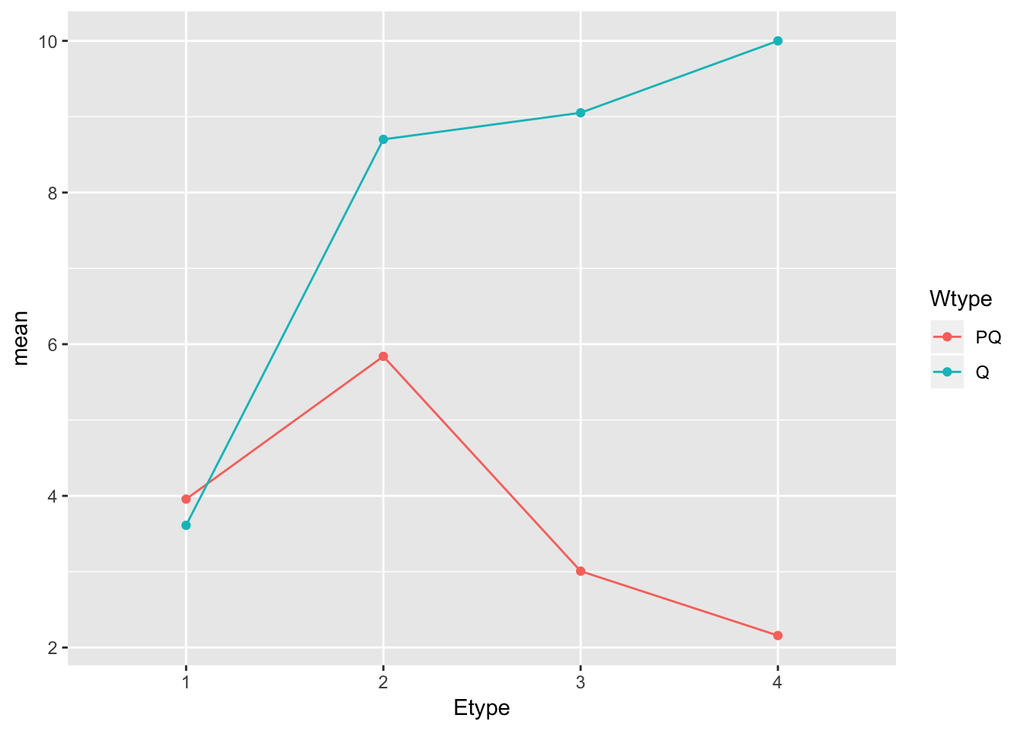

```r
  ggplot(grouped_sat, aes(x=Etype, y=mean, group=Wtype, color = Wtype))+
  geom_line()+
  geom_point()
```

4. *Interpretar el resultado sobre si sólo existen efectos principales o hay interacción entre los factores. Si hay interacción, explicar como se observa esta interacción en el gráfico.*

Se puede obervar como la media depende completamente del tipo de trabajo, mostrando una gran diferencia entre las medias de trabajos cualificados y no cualificados, por lo tanto existe una interacción entre ellos que desvia las medias de cada grupo.

### 7.1.2. ANOVA multifactorial

*A continuación, realizar el análisis ANOVA usando los factores y en su caso, la interacción entre los mismos. Interpretar el resultado del modelo y explicar si los factores (y la interacción entre factores) son significativos para modelar la satisfacción laboral.*

```r
aov_m_fit <- aov(S ~ Wtype * Etype, data = sat)
summary.aov(aov_m_fit)
```

```
##             Df Sum Sq Mean Sq F value   Pr(>F)
## Wtype        1 169.26  169.26  83.689 3.49e-10 ***
## Etype        3  30.72   10.24   5.063  0.00589 **
## Wtype:Etype  3  83.87   27.96  13.823 7.72e-06 ***
## Residuals   30  60.67    2.02
## ---
## Signif. codes:  0 '***' 0.001 '**' 0.01 '*' 0.05 '.' 0.1 ' ' 1
```

En este caso se nos muestra que el tipo de trabajo es muy significativo y que existen diferencias notables entre las varianzas según el tipo de trabajo. La interacción también es significativa, siendo la educación la menor de todas y aún así importante.

### 7.1.3. Adecuación del modelo

*Interpretar la adecuación del modelo ANOVA obtenido usando los gráficos de residuos*

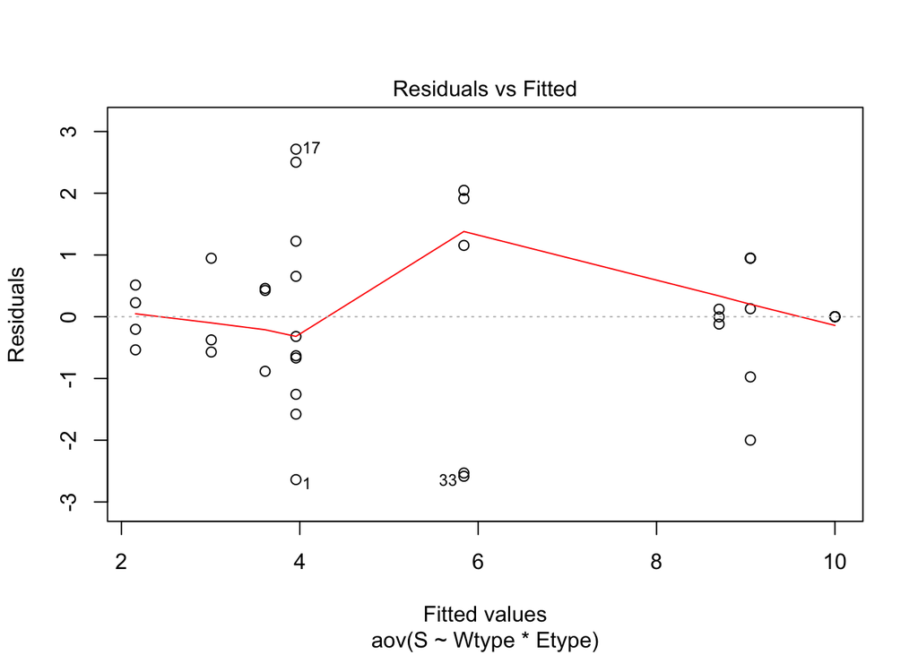

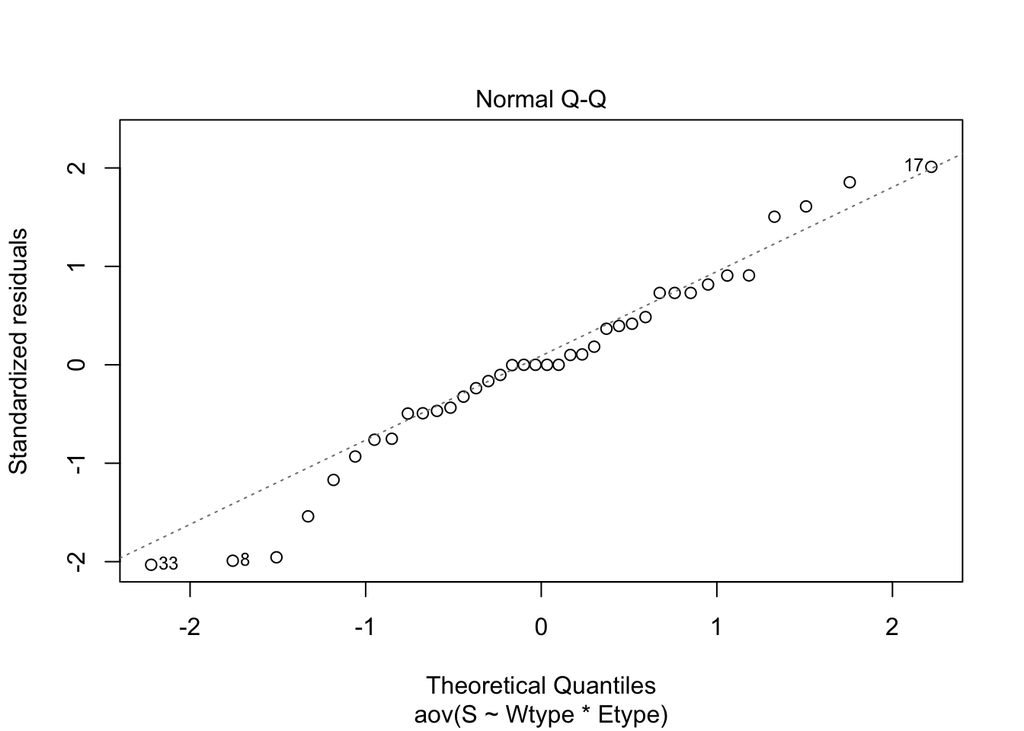

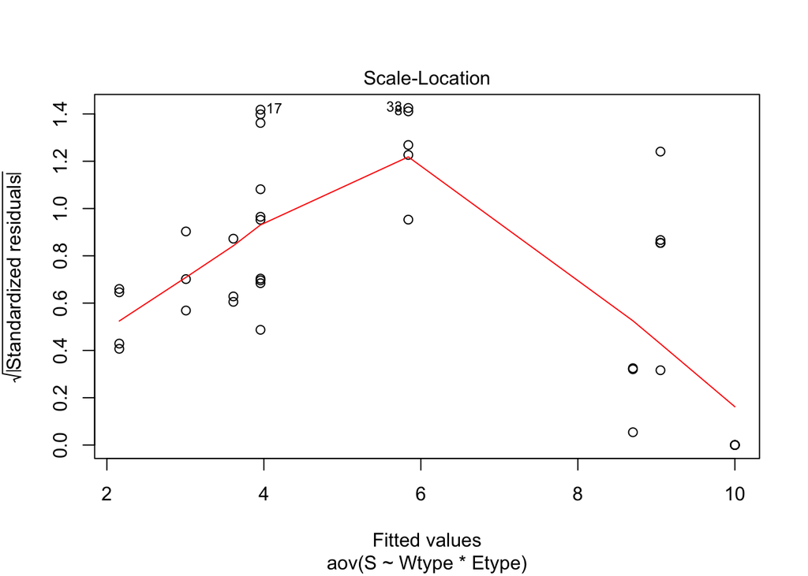

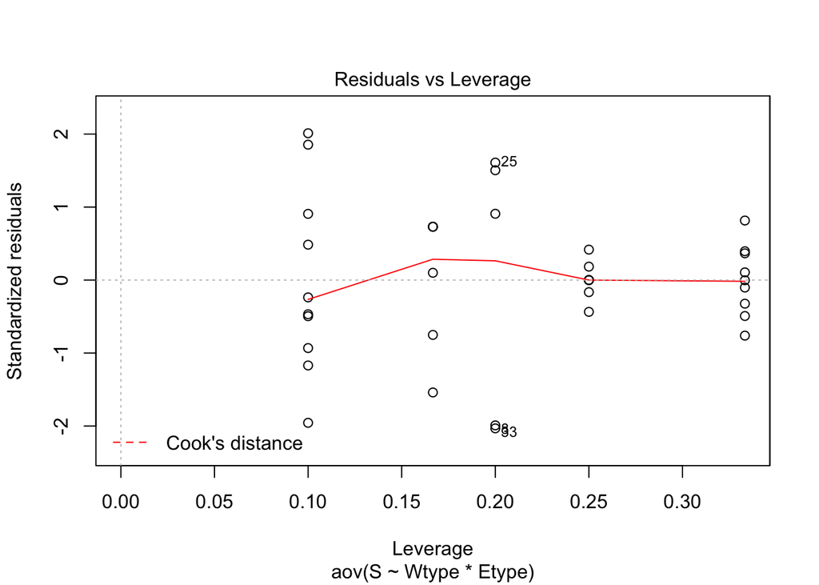

```r
plot(aov_m_fit)
```

En el primer gráfico nos encontramos con que no se puede identificar ningún patrón a simple vista y los puntos se encuentran esparcidos a lo largo de la gráfica, por lo que podriamos supoer que no existe una varianza constante. En el segundo, podemos identificar que en cierta medida sigue una distribución normal salvo en el inicio, por lo que se podría considerar normal con algún sesgo.

En el tercero, se puede observar un pico pero no un patrón como tal, lo que puede indicar que deberiamos de investigar porque se produce un pico, pero no podemos deducir que se trate de variables de varianza constante o no. Por último, nos encontramos con que no se encuentran patrones y los puntos se encuentran a lo largo de la gráfica con distancias similares.

En definitiva, se puede intuir que no existe una varianza constante entre los distintos grupos.

## 7.2. Factores: tipo de trabajo y sexo

### 7.2.1. Análisis visual de los efectos principales y posibles interacciones

*Realizar el análisis visual de los factores tipo de trabajo y sexo, de forma análoga al caso anterior. Interpretar el resultado del gráfico en relación a los efectos principales y posibles interacciones.*

```r
grouped_sat1 <- sat %>%
  group_by(Wtype, Sex) %>%
  summarise(mean = mean(S))

grouped_sat1
```

```
## # A tibble: 4 x 3
## # Groups:   Wtype [?]
##   Wtype Sex    mean
##   <fct> <fct> <dbl>
## 1 PQ    F      3.29
## 2 PQ    M      4.70
## 3 Q     F      9.16
## 4 Q     M      7.88
```

```r
head(inner_join(sat, grouped_sat1, by = c("Wtype", "Sex")) %>% select(Wtype, Sex, mean))
```

```
##   Wtype Sex     mean
## 1    PQ   F 3.285235
## 2    PQ   F 3.285235
## 3    PQ   F 3.285235
## 4    PQ   F 3.285235
## 5     Q   M 7.882529
## 6    PQ   F 3.285235
```

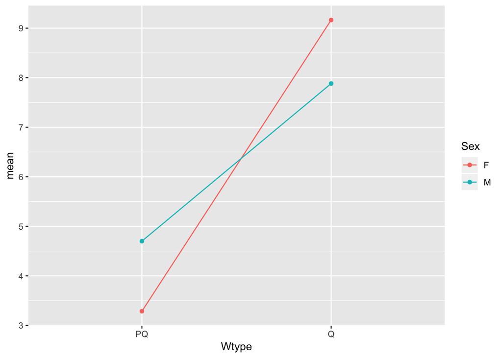

```r
  ggplot(grouped_sat1, aes(x=Wtype, y=mean, group=Sex, color = Sex))+
  geom_line()+
  geom_point()
```

Para este caso se observa una tendencia según el tipo de trabajo, dado que aumenta la media de la satisfacción para cada grupo, con una pequeña diferencia con el tipo de sexo.

### 7.2.2. ANOVA multifactorial

*Realizar el análisis ANOVA con los factores tipo de trabajo, sexo e interacción, en su caso. Interpretar el resultado*

```r
aov_m_fit1 <- aov(S ~ Wtype * Sex, data = sat)
summary.aov(aov_m_fit1)
```

```
##             Df Sum Sq Mean Sq F value  Pr(>F)
## Wtype        1 169.26  169.26  36.100 8.4e-07 ***
## Sex          1   1.77    1.77   0.378  0.5426
## Wtype:Sex    1  14.08   14.08   3.003  0.0922 .
## Residuals   34 159.41    4.69
## ---
## Signif. codes:  0 '***' 0.001 '**' 0.01 '*' 0.05 '.' 0.1 ' ' 1
```

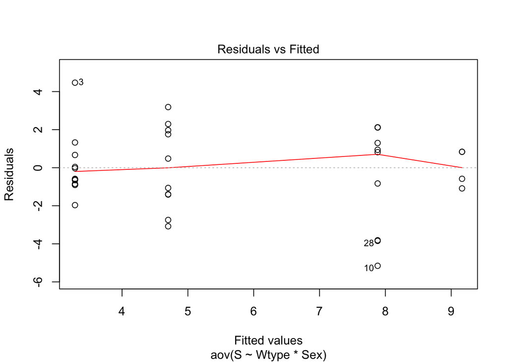

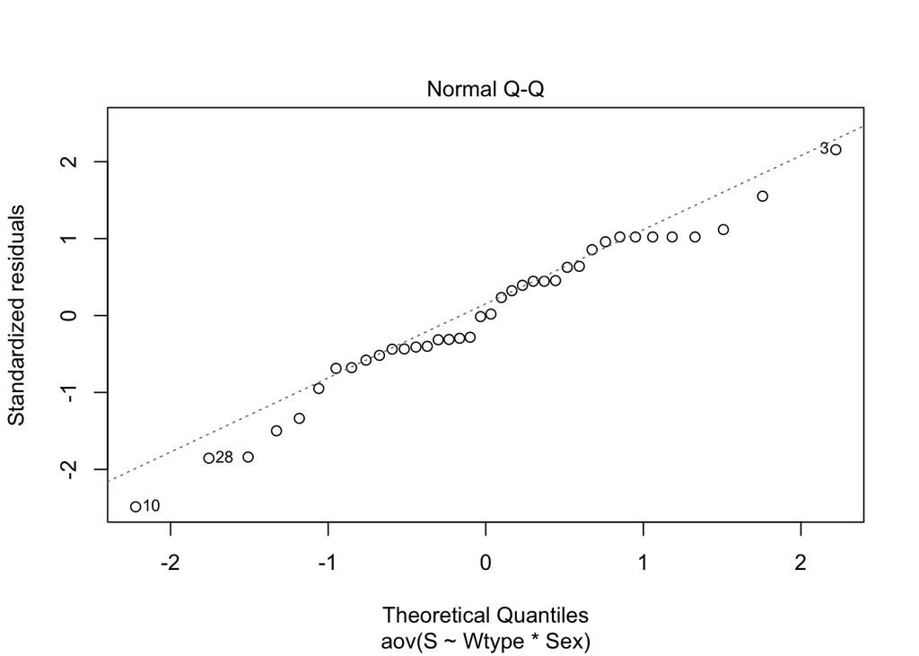

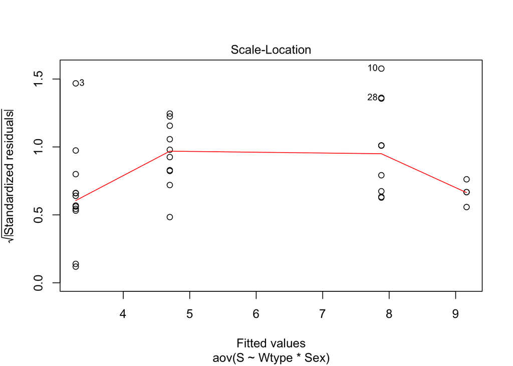

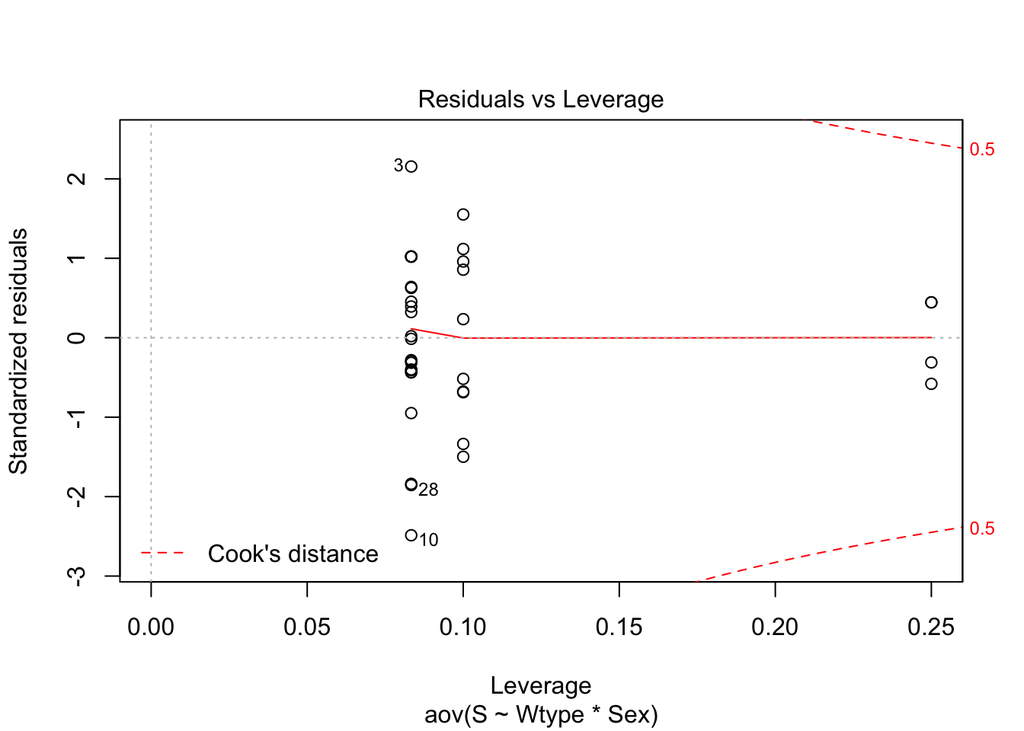

```r
plot(aov_m_fit1)
```

En este caso la interacción y la variable Sex contienen un p-valor mayor al nivel de significación por lo que se considera que existe una similitud de varianzas, mientras que para el tipo de trabajo sigue marcando una gran diferencia entre las varianzas y un alto grado de significación.

# 8. Comparaciones múltiples

*Tomando como referencia el modelo ANOVA multifactorial, con los factores tipo de trabajo y nivel de estudios, aplicar el test de comparación múltiple Scheffé. Interpretar el resultado del test e indicar qué grupos son diferentes significativamente entre sí.*

```r
stest <- scheffe.test(aov_m_fit, "S", group=TRUE,console=FALSE)
stest$statistics
```

```
##    MSerror Df        F     Mean       CV
##   2.022471 30 1.834694 5.728286 24.82656
```

# 9. Conclusiones

*Escribir las conclusiones finales del estudio en relación a los objetivos de la investigación.*

En este caso podemos observar lo siguiente:

- Una de las variables que más afecta a la satisfacción es el tipo de trabajo, mostrando una clara diferencia entre el trabajo cualificado y no cualificado
- El tipo de trabajo es de gran importancia a lo hora de realizar la regresion lineal sobre la variable dependiente
- Existen diferencias de varianza entre los grupos según del tipo de trabajo
- Debido al poco número de observaciones por grupo, no se ha podido considerar que sigue una distribución normal y los análisis la mayoría de los grupos rechazaban la normalidad seún la satisfacción